# Stroke Prediction

### Dataset

According to the World Health Organization (WHO) stroke is the 2nd leading cause of death globally, responsible for approximately 11% of total deaths. This dataset is used to predict whether a patient is likely to get stroke based on the input parameters like gender, age, various diseases, and smoking status. Each row in the data provides relavant information about the patient.

Attribute Information

1. id: unique identifier
2. gender: "Male", "Female" or "Other"
3. age: age of the patient
4. hypertension: 0 if the patient doesn't have hypertension, 1 if the patient has hypertension
5. heart_disease: 0 if the patient doesn't have any heart diseases, 1 if the patient has a heart disease
6. ever_married: "No" or "Yes"
7. work_type: "children", "Govt_jov", "Never_worked", "Private" or "Self-employed"
8. Residence_type: "Rural" or "Urban"
9. avg_glucose_level: average glucose level in blood
10. bmi: body mass index
11. smoking_status: "formerly smoked", "never smoked", "smokes" or "Unknown"*
12. stroke: 1 if the patient had a stroke or 0 if not

*Note: "Unknown" in smoking_status means that the information is unavailable for this patient

### Experiment

In this program we will use different classification algorithms to determine which of those has the best accuracy.

The classification algorithms used in this program:

1. Decision Tree (with all nodes and only some of them)
2. Naive Bayes
3. K-nearest neighbour (for k = 3 & k = 5 & k = 11)
4. Neural networks

In the first part of experiment our dataset in only preprocessed partly (only with the most important preprocessing techniques). However in the second part we used optimization techniques like normalizing or principal component analysis algorithm (PCA)

##### Author of experiment: Oskar Lewna

```python
import pandas as pd
import matplotlib.pyplot as plt
import tensorflow as tf
from sklearn.model_selection import train_test_split
from sklearn.tree import DecisionTreeClassifier
from sklearn.preprocessing import MinMaxScaler
from sklearn.metrics import accuracy_score
from sklearn.metrics import confusion_matrix
from sklearn.metrics import  ConfusionMatrixDisplay
from sklearn.neighbors import KNeighborsClassifier
from sklearn.naive_bayes import GaussianNB
from sklearn.decomposition import PCA
from keras.models import Sequential
from keras.layers import Dense
```

### There we read the file and delete rows with missing values and remove ID column. Below we can see how the amount of data changed

```python
df = pd.read_csv('healthcare-dataset-stroke-data.csv')

# before removing rows with null and id column
print(df.shape)

gender = {"Female": 0, "Male": 1, "Other": 2}
married = {"No": 0, "Yes": 1}
work_type = {"children": 0,"Govt_job": 1, "Never_worked": 2, "Private": 3,"Self-employed": 4}
residence_type = {"Rural": 0, "Urban": 1}
smoking_status = {"formerly smoked": 0, "never smoked": 1, "smokes": 2}

df['Gender'] = df['Gender'].map(gender)
df['Ever_Married'] = df['Ever_Married'].map(married)
df['Work_Type'] = df['Work_Type'].map(work_type)
df['Residence_Type'] = df['Residence_Type'].map(residence_type)
df['Smoking_Status'] = df['Smoking_Status'].map(smoking_status)

df = df.dropna()
df = df.drop(columns=["ID"])
# after
print(df.shape)
```

```
(43400, 12)
(29072, 11)
```

### Due to imbalanced data we need to use over-sampling to add samples which are less

```
(57568, 11)
```

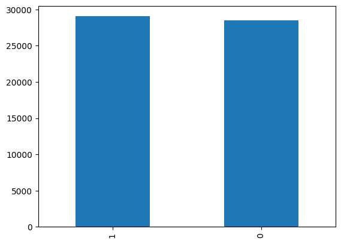

```python
true = df["Stroke"].sum()
rows, cols = df.shape
new_true_amount = (rows-true)//true
new_rows = df[df["Stroke"] == 1]
for i in range(new_true_amount):
    df = pd.concat([df,new_rows])

# after adding more TRUE samples
print(df.shape)
df = df.sample(frac=1)

df['Stroke'].value_counts().plot.bar()
```

### Here we split data to train set and test set

```python
inputs = df.values[:, :-1]
classes = df.values[:, -1]

(train_inputs, test_inputs, train_labels, test_labels) = train_test_split(inputs, classes, train_size=0.7, random_state=278779)
```

# Firstly we will classify dataset with a bit of preprocessing

### Decision Tree with all nodes

```
0.9876092872445139
```

```
<sklearn.metrics._plot.confusion_matrix.ConfusionMatrixDisplay at 0x219d36c7190>
```

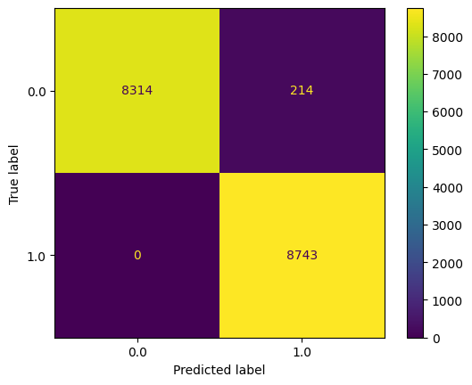

```python
dtc = DecisionTreeClassifier(random_state=278779)

dtc = dtc.fit(train_inputs, train_labels)

print(dtc.score(test_inputs, test_labels))

predictions = dtc.predict(test_inputs)
cm = confusion_matrix(test_labels, predictions)
disp = ConfusionMatrixDisplay(confusion_matrix=cm, display_labels=dtc.classes_)
disp.plot()
```

### Decision Tree with 10 layers of nodes

```
0.8576805048925945
```

```
<sklearn.metrics._plot.confusion_matrix.ConfusionMatrixDisplay at 0x219cfbd48b0>
```

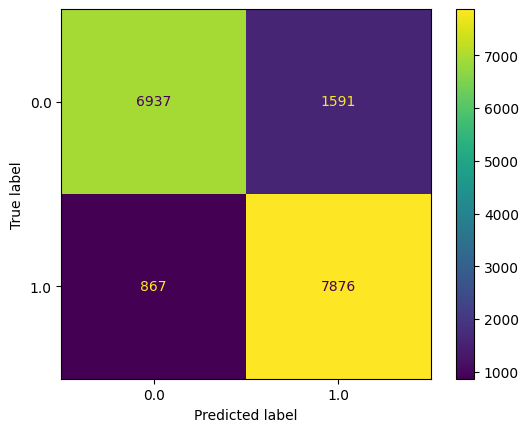

```python
dtc = DecisionTreeClassifier(random_state=278779, max_depth=10)

dtc = dtc.fit(train_inputs, train_labels)

print(dtc.score(test_inputs, test_labels))

predictions = dtc.predict(test_inputs)
cm = confusion_matrix(test_labels, predictions)
disp = ConfusionMatrixDisplay(confusion_matrix=cm, display_labels=dtc.classes_)
disp.plot()
```

### Naive Bayes

```
0.7515488390944357
```

```
<sklearn.metrics._plot.confusion_matrix.ConfusionMatrixDisplay at 0x219c9f767d0>
```

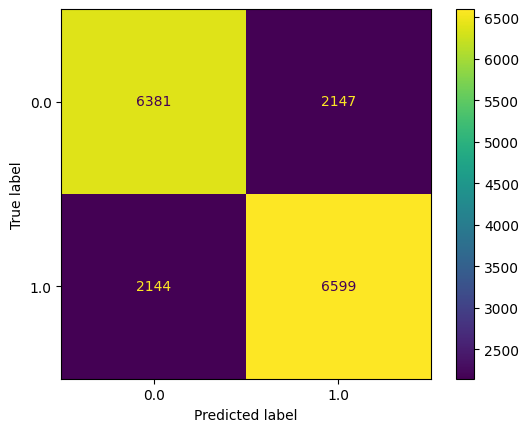

```python
bayes = GaussianNB()
bayes.fit(train_inputs, train_labels)
predictions = bayes.predict(test_inputs)

print(bayes.score(test_inputs, test_labels))

cm = confusion_matrix(test_labels,predictions,labels=bayes.classes_)
disp = ConfusionMatrixDisplay(confusion_matrix=cm,display_labels=bayes.classes_)
disp.plot()
```

### K-nearest neighbors (KNN) where k=3

```
0.9751027734352382
```

```
<sklearn.metrics._plot.confusion_matrix.ConfusionMatrixDisplay at 0x219d0fd5bd0>
```

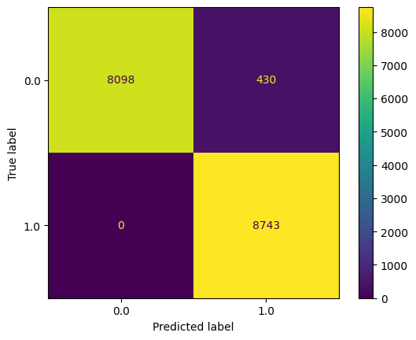

```python
knn = KNeighborsClassifier(n_neighbors=3, metric='euclidean')
knn.fit(train_inputs, train_labels)
predictions = knn.predict(test_inputs)

print(knn.score(test_inputs, test_labels))

cm = confusion_matrix(test_labels,predictions,labels=knn.classes_)
disp = ConfusionMatrixDisplay(confusion_matrix=cm,display_labels=knn.classes_)
disp.plot()
```

### K-nearest neighbors (KNN) where k=5

```
0.9644490764865961
```

```
<sklearn.metrics._plot.confusion_matrix.ConfusionMatrixDisplay at 0x219c9df2ce0>
```

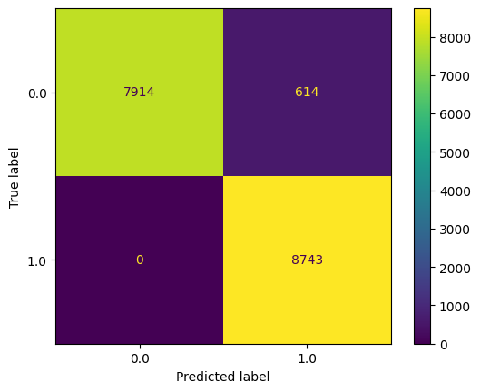

```python
knn = KNeighborsClassifier(n_neighbors=5, metric='euclidean')
knn.fit(train_inputs, train_labels)
predictions = knn.predict(test_inputs)

print(knn.score(test_inputs, test_labels))

cm = confusion_matrix(test_labels,predictions,labels=knn.classes_)
disp = ConfusionMatrixDisplay(confusion_matrix=cm,display_labels=knn.classes_)
disp.plot()
```

### K-nearest neighbors (KNN) where k=11

```
0.9374095304267269
```

```
<sklearn.metrics._plot.confusion_matrix.ConfusionMatrixDisplay at 0x219c18ba770>
```

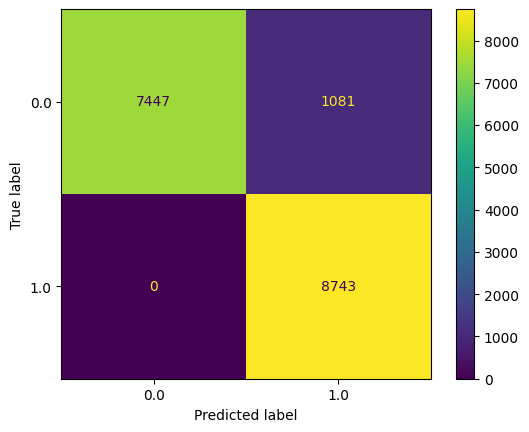

```python
knn = KNeighborsClassifier(n_neighbors=11, metric='euclidean')
knn.fit(train_inputs, train_labels)
predictions = knn.predict(test_inputs)

print(knn.score(test_inputs, test_labels))

cm = confusion_matrix(test_labels,predictions,labels=knn.classes_)
disp = ConfusionMatrixDisplay(confusion_matrix=cm,display_labels=knn.classes_)
disp.plot()
```

### Neural network

```python
train_inputs_n = tf.convert_to_tensor(train_inputs, dtype=tf.float32)
test_inputs_n = tf.convert_to_tensor(test_inputs, dtype=tf.float32)
train_labels_n = tf.convert_to_tensor(train_labels, dtype=tf.float32)
test_labels_n = tf.convert_to_tensor(test_labels, dtype=tf.float32)
```

```
0.7558913786115453
```

```
<sklearn.metrics._plot.confusion_matrix.ConfusionMatrixDisplay at 0x219c76f8a30>
```

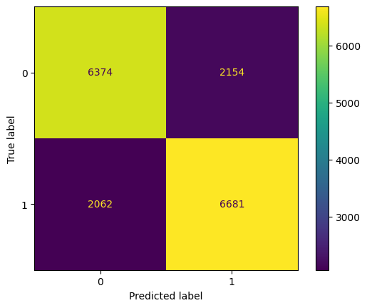

```python
model = Sequential()
model.add(Dense(6, activation='relu', input_dim=train_inputs_n.shape[1]))
model.add(Dense(3, activation='relu'))
model.add(Dense(1, activation='sigmoid'))

model.compile(optimizer='adam', loss='binary_crossentropy', metrics=['accuracy'])

history = model.fit(train_inputs_n, train_labels_n, epochs=100, verbose=0, validation_data=(test_inputs_n, test_labels_n))

predictions = model.predict(test_inputs_n).round()
print(accuracy_score(predictions, test_labels_n))

cm = confusion_matrix(test_labels_n,predictions)
disp = ConfusionMatrixDisplay(confusion_matrix=cm,display_labels=[0,1])
disp.plot()
```

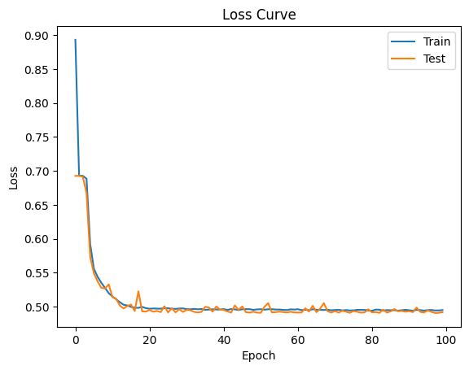

```python
train_loss = history.history['loss']
val_loss = history.history['val_loss']

plt.plot(train_loss, label='Train')
plt.plot(val_loss, label='Test')
plt.title('Loss Curve')
plt.xlabel('Epoch')
plt.ylabel('Loss')
plt.legend()
plt.show()
```

```
0.7589022060100747
```

```
<sklearn.metrics._plot.confusion_matrix.ConfusionMatrixDisplay at 0x219c8c1be50>
```

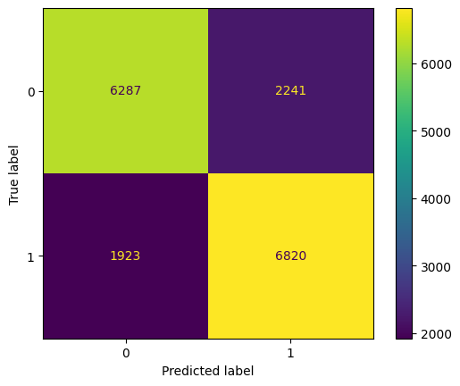

```python
model = Sequential()
model.add(Dense(4, activation='relu', input_dim=train_inputs_n.shape[1]))
model.add(Dense(3, activation='relu'))
model.add(Dense(3, activation='relu'))
model.add(Dense(1, activation='sigmoid'))

model.compile(optimizer='adam', loss='binary_crossentropy', metrics=['accuracy'])

history = model.fit(train_inputs_n, train_labels_n, epochs=100, verbose=0, validation_data=(test_inputs_n, test_labels_n))

predictions = model.predict(test_inputs_n).round()
print(accuracy_score(predictions, test_labels_n))

cm = confusion_matrix(test_labels_n,predictions)
disp = ConfusionMatrixDisplay(confusion_matrix=cm,display_labels=[0,1])
disp.plot()
```

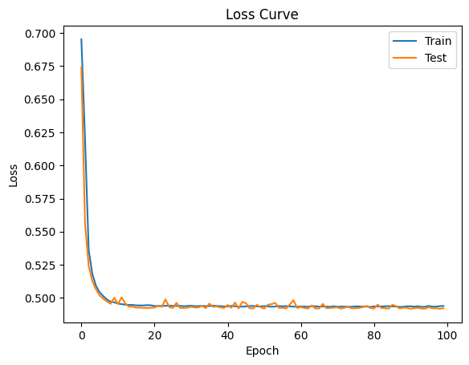

```python
train_loss = history.history['loss']
val_loss = history.history['val_loss']

plt.plot(train_loss, label='Train')
plt.plot(val_loss, label='Test')
plt.title('Loss Curve')
plt.xlabel('Epoch')
plt.ylabel('Loss')
plt.legend()
plt.show()
```

# Now we will use preprocessing and normalize our data

### We scale our data with min-max scaling to reduce data in column to values from 0 to 1. Then we use PCA algorithm to reduce it even more and at the end we split data to train set and test set

```python
scaler = MinMaxScaler()
scaler.fit(df)
df_scaler = scaler.transform(df)
df = pd.DataFrame(df_scaler, columns=df.columns)
print(df.head())

inputs = df.values[:, :-1]
classes = df.values[:, -1]

pca= PCA(n_components=10).fit(inputs)
# print(pca)
# print(pca.explained_variance_ratio_)
# print(pca.components_)
print(pca.transform(inputs))
inputs = pca.transform(inputs)

(train_inputs, test_inputs, train_labels, test_labels) = train_test_split(inputs, classes, train_size=0.7, random_state=278779)
```

```
   Gender       Age  Hypertension  Heart_Disease  Ever_Married  Work_Type  \
0     0.0  0.375000           0.0            0.0           1.0       1.00
1     0.0  0.944444           0.0            1.0           1.0       1.00
2     0.0  0.736111           1.0            0.0           1.0       0.75
3     0.5  0.375000           0.0            0.0           0.0       0.25
4     0.0  0.625000           0.0            0.0           1.0       0.75

   Residence_Type  Avg_Glucose_Level       BMI  Smoking_Status  Stroke
0             0.0           0.150483  0.333333             1.0     0.0
1             0.0           0.177766  0.301587             0.5     1.0
2             1.0           0.619598  0.188034             0.5     0.0
3             0.0           0.208312  0.216117             0.5     0.0
4             0.0           0.106931  0.189255             0.5     0.0
[[-0.53876789 -0.29001842 -0.15986911 ... -0.1469411  -0.28864933
   0.08350469]
 [-0.54709108  0.37871009 -0.2918493  ... -0.2850844  -0.01690297
   0.08863556]
 [ 0.52833797  0.57994913  0.46619749 ...  0.25077652 -0.14738718
  -0.10020555]
 ...
 [-0.49812259  0.07560228 -0.29117866 ... -0.12061771  0.11852752
  -0.09167947]
 [ 0.48202358 -0.00904687 -0.31958704 ... -0.03144266  0.17096538
   0.0941825 ]
 [-0.48956489 -0.89622949  0.48623093 ... -0.12697871 -0.21895356
   0.10237225]]
```

## Now we use the same classifiers as above but this time with **normalized** data

### Decision Tree with all nodes after preprocessing

```
0.9876092872445139
```

```
<sklearn.metrics._plot.confusion_matrix.ConfusionMatrixDisplay at 0x219bc5f9510>
```

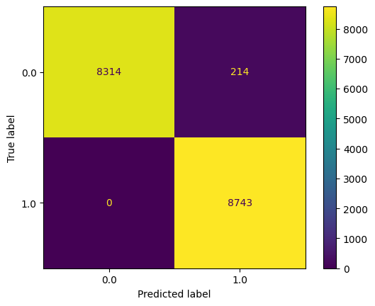

```python
dtc = DecisionTreeClassifier(random_state=278779)

dtc = dtc.fit(train_inputs, train_labels)

print(dtc.score(test_inputs, test_labels))

predictions = dtc.predict(test_inputs)
cm = confusion_matrix(test_labels, predictions)
disp = ConfusionMatrixDisplay(confusion_matrix=cm, display_labels=dtc.classes_)
disp.plot()
```

### Decision tree with 10 layers of nodes after preprocessing

```
0.8900468994267848
```

```
<sklearn.metrics._plot.confusion_matrix.ConfusionMatrixDisplay at 0x219bbb97580>
```

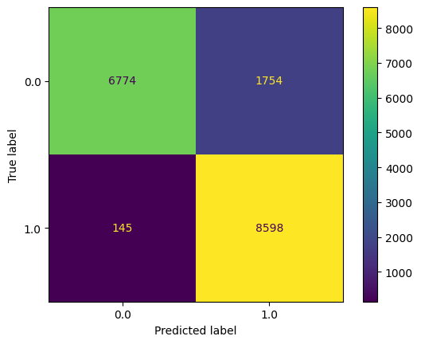

```python
dtc = DecisionTreeClassifier(random_state=278779, max_depth=10)

dtc = dtc.fit(train_inputs, train_labels)

print(dtc.score(test_inputs, test_labels))

predictions = dtc.predict(test_inputs)
cm = confusion_matrix(test_labels, predictions)
disp = ConfusionMatrixDisplay(confusion_matrix=cm, display_labels=dtc.classes_)
disp.plot()
```

### Naive Bayes after preprocessing

```
0.7645185571188697
```

```
<sklearn.metrics._plot.confusion_matrix.ConfusionMatrixDisplay at 0x219c2c85870>
```

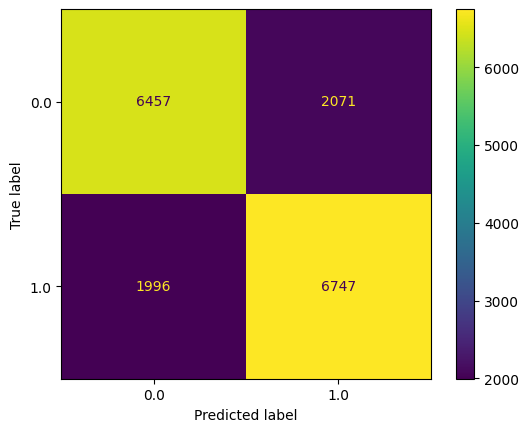

```python
bayes = GaussianNB()
bayes.fit(train_inputs, train_labels)
predictions = bayes.predict(test_inputs)

print(bayes.score(test_inputs, test_labels))

cm = confusion_matrix(test_labels,predictions,labels=bayes.classes_)
disp = ConfusionMatrixDisplay(confusion_matrix=cm,display_labels=bayes.classes_)
disp.plot()
```

### K-nearest neighbors (KNN) where k=3 after preprocessing

```
0.9747553702738695
```

```
<sklearn.metrics._plot.confusion_matrix.ConfusionMatrixDisplay at 0x219c9cbde10>
```

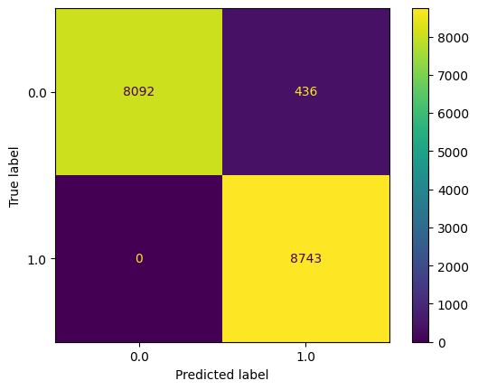

```python
knn = KNeighborsClassifier(n_neighbors=3, metric='euclidean')
knn.fit(train_inputs, train_labels)
predictions = knn.predict(test_inputs)

print(knn.score(test_inputs, test_labels))

cm = confusion_matrix(test_labels,predictions,labels=knn.classes_)
disp = ConfusionMatrixDisplay(confusion_matrix=cm,display_labels=knn.classes_)
disp.plot()
```

### K-nearest neighbors (KNN) where k=5 after preprocessing

```
0.9639858722714376
```

```
<sklearn.metrics._plot.confusion_matrix.ConfusionMatrixDisplay at 0x219bbb37520>
```

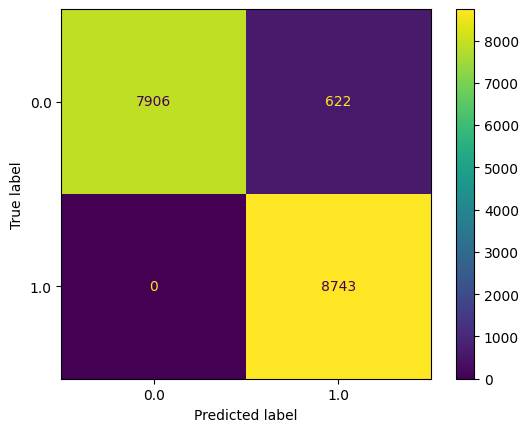

```python
knn = KNeighborsClassifier(n_neighbors=5, metric='euclidean')
knn.fit(train_inputs, train_labels)
predictions = knn.predict(test_inputs)

print(knn.score(test_inputs, test_labels))

cm = confusion_matrix(test_labels,predictions,labels=knn.classes_)
disp = ConfusionMatrixDisplay(confusion_matrix=cm,display_labels=knn.classes_)
disp.plot()
```

### K-nearest neighbors (KNN) where k=11 after preprocessing

```
0.9346882056626715
```

```
<sklearn.metrics._plot.confusion_matrix.ConfusionMatrixDisplay at 0x219bd0dceb0>
```

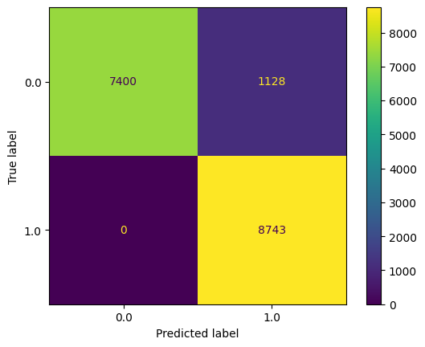

```python
knn = KNeighborsClassifier(n_neighbors=11, metric='euclidean')
knn.fit(train_inputs, train_labels)
predictions = knn.predict(test_inputs)

print(knn.score(test_inputs, test_labels))

cm = confusion_matrix(test_labels,predictions,labels=knn.classes_)
disp = ConfusionMatrixDisplay(confusion_matrix=cm,display_labels=knn.classes_)
disp.plot()
```

### Neural network after preprocessing

```python
train_inputs_n = tf.convert_to_tensor(train_inputs, dtype=tf.float32)
test_inputs_n = tf.convert_to_tensor(test_inputs, dtype=tf.float32)
train_labels_n = tf.convert_to_tensor(train_labels, dtype=tf.float32)
test_labels_n = tf.convert_to_tensor(test_labels, dtype=tf.float32)
```

```
0.777430374616409
```

```
<sklearn.metrics._plot.confusion_matrix.ConfusionMatrixDisplay at 0x219bd348e20>
```

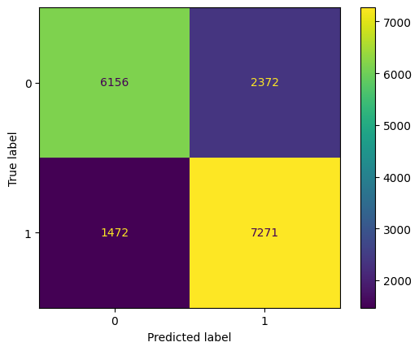

```python
model = Sequential()
model.add(Dense(6, activation='relu', input_dim=train_inputs_n.shape[1]))
model.add(Dense(3, activation='relu'))
model.add(Dense(1, activation='sigmoid'))

model.compile(optimizer='adam', loss='binary_crossentropy', metrics=['accuracy'])

history = model.fit(train_inputs_n, train_labels_n, epochs=100, verbose=0, validation_data=(test_inputs_n, test_labels_n))

predictions = model.predict(test_inputs_n).round()
print(accuracy_score(predictions, test_labels_n))

cm = confusion_matrix(test_labels_n,predictions)
disp = ConfusionMatrixDisplay(confusion_matrix=cm,display_labels=[0,1])
disp.plot()
```

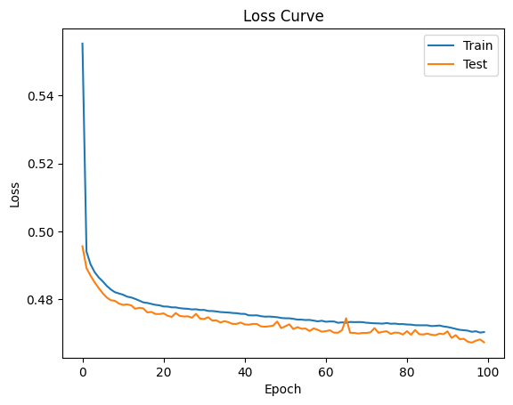

```python
train_loss = history.history['loss']
val_loss = history.history['val_loss']

plt.plot(train_loss, label='Train')
plt.plot(val_loss, label='Test')
plt.title('Loss Curve')
plt.xlabel('Epoch')
plt.ylabel('Loss')
plt.legend()
plt.show()
```

```
0.7708876150772972
```

```
<sklearn.metrics._plot.confusion_matrix.ConfusionMatrixDisplay at 0x219d2730880>
```

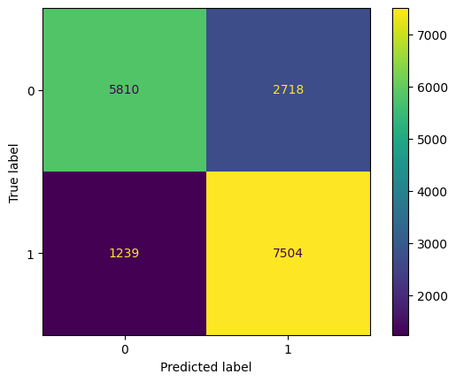

```python
model = Sequential()
model.add(Dense(4, activation='relu', input_dim=train_inputs_n.shape[1]))
model.add(Dense(3, activation='relu'))
model.add(Dense(3, activation='relu'))
model.add(Dense(1, activation='sigmoid'))

model.compile(optimizer='adam', loss='binary_crossentropy', metrics=['accuracy'])

history = model.fit(train_inputs_n, train_labels_n, epochs=100, verbose=0, validation_data=(test_inputs_n, test_labels_n))

predictions = model.predict(test_inputs_n).round()
print(accuracy_score(predictions, test_labels_n))

cm = confusion_matrix(test_labels_n,predictions)
disp = ConfusionMatrixDisplay(confusion_matrix=cm,display_labels=[0,1])
disp.plot()
```

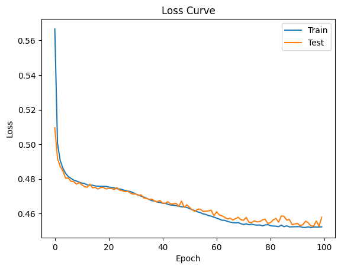

```python
train_loss = history.history['loss']
val_loss = history.history['val_loss']

plt.plot(train_loss, label='Train')
plt.plot(val_loss, label='Test')
plt.title('Loss Curve')
plt.xlabel('Epoch')
plt.ylabel('Loss')
plt.legend()
plt.show()
```

# **To sum up**

| Classifier | Normal dataset | Preprocessed dataset |
| --- | --- | --- |
| Decision tree (all nodes) | 98.76% | 98.76% |
| Decision tree (10 nodes) | 85.76% | 89.00% |
| Naive Bayes | 75.15% | 76.45% |
| KNN k=3 | 97.51% | 97.48% |
| KNN k=5 | 96.44% | 96.40% |
| KNN k=11 | 93.74% | 93.47% |
| Neural network 1 | 75.58% | 77.74% |
| Neural network 2 | 75.89% | 77.09% |

### Bibliography

Original dataset - https://www.kaggle.com/datasets/fedesoriano/stroke-prediction-dataset Enlarged dataset - https://www.kaggle.com/datasets/swetha0406/heart-stroke-prediction sklearn documentation - https://scikit-learn.org/stable/supervised_learning.html#supervised-learning pandas documentation - https://pandas.pydata.org/docs/reference/general_functions.html and lectures